# Practical Machine Learning Course Project Report

Sanjeeb, kc

April 30, 2016

### Load data

- Load data.
- Remove near zero covariates and those with more than 80% missing values since these variables will not provide much power for prediction.
- Calculate correlations between each remaining feature to the response, `classe`. Use `spearman` rank based correlation because `classe` is a factor.
- Plot the two features that have highest correlation with `classe` and color with `classe` to see if we can separate response based on these features.

```r
# load data
training <- read.csv("./data/pml-training.csv", row.names = 1)
testing <- read.csv("./data/pml-testing.csv", row.names = 1)
# remove near zero covariates
nsv <- nearZeroVar(training, saveMetrics = T)
training <- training[, !nsv$nzv]
# remove variables with more than 80% missing values
nav <- sapply(colnames(training), function(x) if(sum(is.na(training[, x])) > 0.8*nrow(training)){return(T)}else{return(F)})
training <- training[, !nav]
# calculate correlations
cor <- abs(sapply(colnames(training[, -ncol(training)]), function(x) cor(as.numeric(training[, x]), as.numeric(training$classe), method = "spearman")))
```

```r
# plot predictors
summary(cor)
```

```
##    Min. 1st Qu.  Median    Mean 3rd Qu.    Max.
##  0.0015  0.0147  0.0524  0.0862  0.1370  0.3170
```

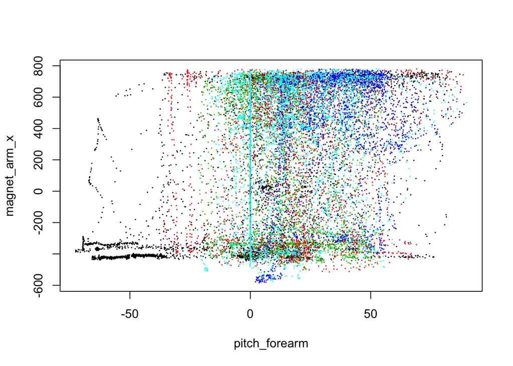

```r
plot(training[, names(which.max(cor))], training[, names(which.max(cor[-which.max(cor)]))], col = training$classe, pch = 19, cex = 0.1, xlab = names(which.max(cor)), ylab = names(which.max(cor[-which.max(cor)])))
```

The training set has **19622** samples and **57** potential predictors after filtering.

There doesn’t seem to be any strong predictors that correlates with `classe` well, so linear regression model is probably not suitable in this case. Boosting and random forests algorithms may generate more robust predictions for our data.

### Boosting model

- Fit model with boosting algorithm and 10-fold cross validation to predict `classe` with all other predictors.
- Plot accuracy of this model on the scale `[0.9, 1]`.

```r
set.seed(123)
boostFit <- train(classe ~ ., method = "gbm", data = training, verbose = F, trControl = trainControl(method = "cv", number = 10))
```

```r
boostFit
```

[output not shown]

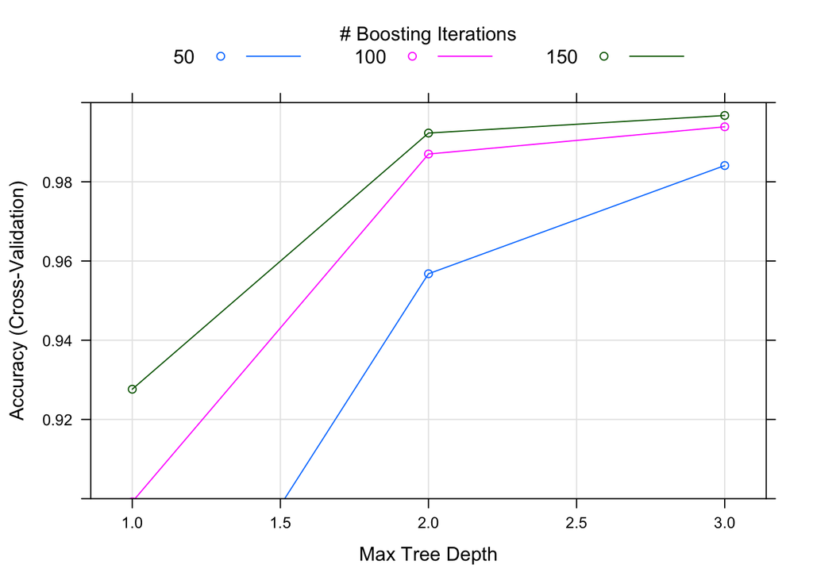

```r
plot(boostFit, ylim = c(0.9, 1))
```

The boosting algorithm generated a good model with **accuracy = 0.997**.

### Random forests model

- Fit model with random forests algorithm and 10-fold cross validation to predict `classe` with all other predictors.
- Plot accuracy of the model on the **same scale** as boosting model.

```r
set.seed(123)
rfFit <- train(classe ~ ., method = "rf", data = training, importance = T, trControl = trainControl(method = "cv", number = 10))
```

```r
rfFit
```

[output not shown]

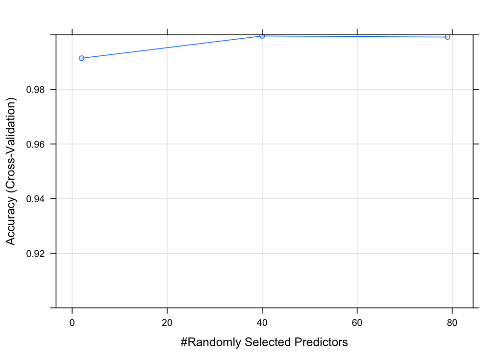

```r
plot(rfFit, ylim = c(0.9, 1))
```

The random forests algorithm generated a very accurate model with **accuracy close to 1**. Compared to boosting model, this model generally has better performance in terms of accuracy as we see from the plots.

### Final model and prediction

- Comparing model accuracy of the two models generated, random forests and boosting, random forests model has overall better accuracy. So, I’ll use this model for prediction.
- The final random forests model contains 500 trees with 40 variables tried at each split. The five most important predictors in this model are raw_timestamp_part_1, roll_belt, num_window, pitch_forearm, cvtd_timestamp30/11/2011 17:12.
- Estimated **out of sample error rate** for the random forests model is **0.04%** as reported by the final model.
- Predict the test set and output results for automatic grader.

```r
# final model
rfFit$finalModel
```

```
##
## Call:
##  randomForest(x = x, y = y, mtry = param$mtry, importance = ..1)
##                Type of random forest: classification
##                      Number of trees: 500
## No. of variables tried at each split: 40
##
##         OOB estimate of  error rate: 0.04%
## Confusion matrix:
##      A    B    C    D    E class.error
## A 5580    0    0    0    0   0.0000000
## B    1 3796    0    0    0   0.0002634
## C    0    3 3419    0    0   0.0008767
## D    0    0    1 3214    1   0.0006219
## E    0    0    0    1 3606   0.0002772
```

```r
# prediction
(prediction <- as.character(predict(rfFit, testing)))
```

```
##  [1] "B" "A" "B" "A" "A" "E" "D" "B" "A" "A" "B" "C" "B" "A" "E" "E" "A"
## [18] "B" "B" "B"
```

```r
# write prediction files
pml_write_files = function(x){
  n = length(x)
  for(i in 1:n){
    filename = paste0("./prediction/problem_id_", i, ".txt")
    write.table(x[i], file = filename, quote = FALSE, row.names = FALSE, col.names = FALSE)
  }
}
pml_write_files(prediction)
```